# Module 4 Assignment Rmarkdown

Sarah Hodgson

2025-04-10

# 3.10 Assignment: End-to-end data analysis in R

This assignment is to develop a full end-to-end analysis of a dataset in R, designed to show how you can now take any dataset and use your skills as a marine data scientist to build impressive analyses and data visualisations that you can share with end-users.

Note: this assignment relies on the skills developed in Workshop 3, including tidyr, to clean data.

In this assignment, I used real-world marine data collected as part of Queensland fisheries QFISH database to develop a report suitable for reporting to a manager, a community group or for my own research.

### Part 1. Obtaining data.

1. Review all of the available datasets in QFISH & identify which one I will analyse.

   Chosen dataset: Commercial Otter Trawl Fishery
2. Export the dataset in an appropriate format for R (CSV file).
3. Use my Github repo to save the data in an appropriate place. Ensure I sync my github regularly by committing and pushing to the remote repository.
4. Read dataset & check if it displays correctly

```r
library(tidyverse)

#read csv file
qfish <- read.csv("../data/QFISH.csv")

qfish
```

```
##       CalendarYear Licences    Days     Tonnes
## 1             1990      865   91448   4,189.06
## 2             1991      865   90594   3,884.58
## 3             1992      796   84469      5,425
## 4             1993      816   97228  10,384.64
## 5             1994      758   93898   9,787.59
## 6             1995      756   97845  13,201.66
## 7             1996      774  105199  12,309.69
## 8             1997      771  109624  14,275.69
## 9             1998      757  106127  16,013.44
## 10            1999      739  100382  14,578.22
## 11            2000      711   91873  12,157.73
## 12            2001      586   69129  11,225.69
## 13            2002      521   67932  10,080.14
## 14            2003      508   66646  10,460.95
```

[output cut: 22 more lines]

### Part 2. Tidy the data.

5. Using the tidyverse, get my data ready for making a plot.

```r
# Clean the Tonnes column: remove commas and convert to numeric
qfish$Tonnes <- as.numeric(gsub(",", "", qfish$Tonnes))
```

6. Develop a plot to visualise the relationship between the number of fishing licences permitted and the tonnes of catch.

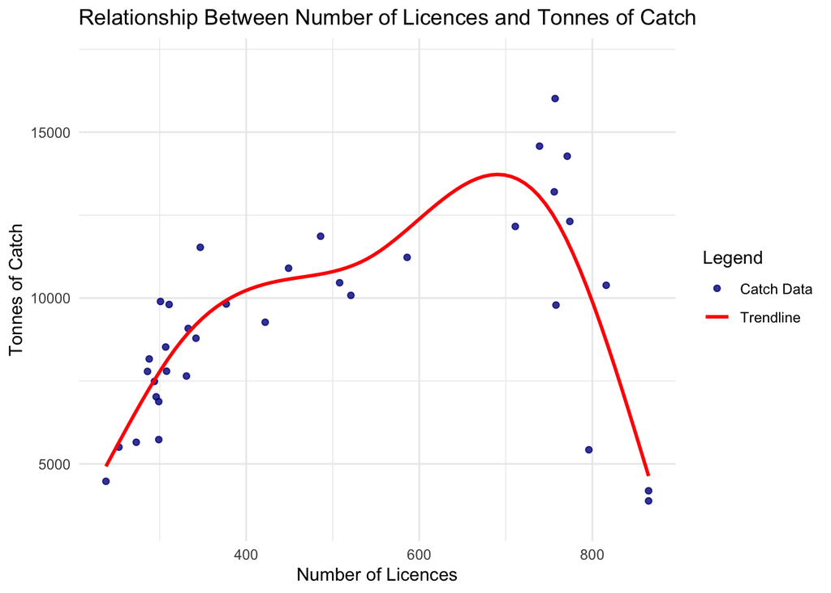

```r
# Remove the outlier (highest Tonnes value)
qfish_no_outlier <- qfish[qfish$Tonnes < max(qfish$Tonnes, na.rm = TRUE), ]

# Create scatter plot
licences_tonnes_plot <- ggplot() +
  geom_point(data = qfish_no_outlier, aes(x = Licences, y = Tonnes, color = "Catch Data"), # add data points, set x & y axes, colour Catch Data points
             alpha = 0.8, size = 1.5) + # transparency & size of data points
  geom_smooth(data = qfish_no_outlier, aes(x = Licences, y = Tonnes, color = "Trendline"), # add trend line, set x & y axes, colour Trendline
              method = "gam", se = FALSE, size = 1) + # use Generalised Additive Models (gam) for the trend line to make it fit the data more accurately
  scale_color_manual(
    name = "Legend", # make legend & name
    values = c("Catch Data" = "darkblue", "Trendline" = "red") # add colours to Catch data & Trend line
  ) +
  scale_y_continuous(expand = expansion(mult = c(0.1, 0.15))) + # adjust scale
  labs(
    title = "Relationship Between Number of Licences and Tonnes of Catch", # name figure
    x = "Number of Licences", # name x axis
    y = "Tonnes of Catch" # name y axis
  ) +
  theme_minimal() # make theme

licences_tonnes_plot
```

7. Save plot & name, specify device to use, dimensions, units, & resolution.

```r
ggsave("licences_tonnes_plot.png", plot = licences_tonnes_plot, device = "png", width = 120, height = 80, units = "mm", dpi = 300)
```